#### Determinants

*The purpose of computation is insight, not numbers*. - Richard Hamming

Some transformations stretch the space while others squish it. It will be good to know how much does a trasformation stretches or squishes the space. Area is a good measure. For example consider the transformation,

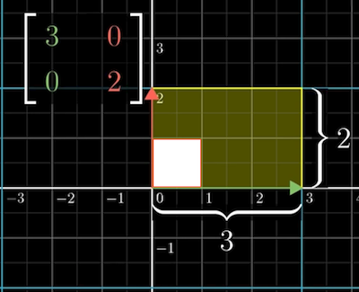

The new area is $3 \times 2 = 6$. Whereas for a sheer like this,

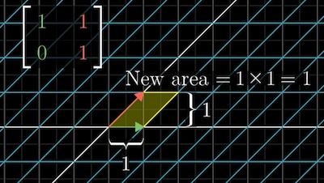

the area remains fixed. Even though this sheer transformation seems to squish things around, the area remains the same, at least in the case of 1 unit square. In fact, if we know how one unit square changes, we can know how any area changes, because linear transformations leave grid lines parallel and evenly spaced.

This special scaling factor, the factor by which the linear transformation changes any area is called the *determinant* of that transformation.

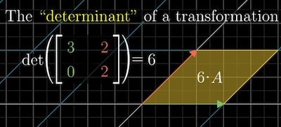

For example, the determinant of a transformation is $3$ if it increases the area after transformation, by $3$.

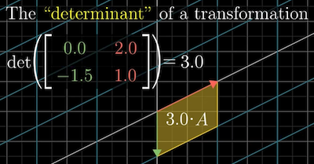

The determinant of a 2D transformation is zero of it squshes all the plane into a single line.

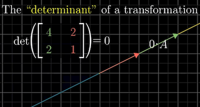

This is a pretty important concept because it will allow us to determine if the transformation reduces our points into a smaller dimenstions.

**Note**: Whatever we said about determinants is when determinant is a positive quantity.

What does a negative determinant even mean? It has to do with the idea of orientation. Any tranformation that flips the axes is said to invert the orientation of space.

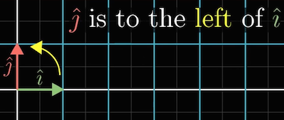

After transformation if the axes direction are reversed:

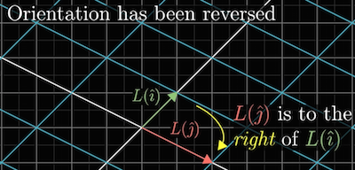

the determinant of such transformations will be negative. The absolute value will still tell us by which factor the area is scaled. Another way to think about this is as follows:

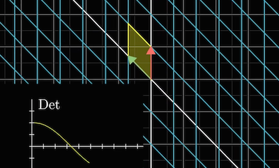

The idea of determinants representing area extends to three dimensions. In this case we will have *parallelopiped* instead of parallelogram’s. A volume of zero means the entire parallelopiped gets squished into zero volume, meaning the vectors would either lie on a plane, or a line or become a single point. This means the columns of the matrix are linearly dependent (i.e, one is a multiple of the other).

What does negative determinant mean in 3-dimensions? Right hand and left hand rule:

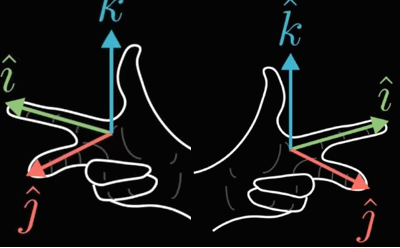

How do we compute determinants?

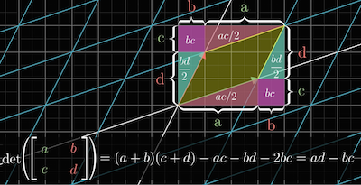

#### Inverse matrices, rank and null space

*To ask the right question is harder than to answer it*. - Georg Cantor

Several real world applications come in the form of linear equations. Even in the case of non-linear equations, they can be approximated by linear equations to a good degree. Linear algebra is very useful in solving such equations. Here is how we think about matrices:

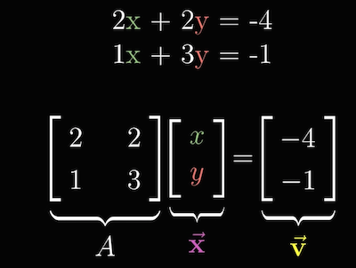

In general, the solution of this would depend on how $A$ behaves - whether it squishes all points to a line (or a point) or not. Thus, $det(A)$ would determine the solution(s). For every transformation $A$, where $det(A) \neq 0$, we can apply the inverse of the transformation. Thus, for instance, if we rotate by $90^{\circ}$ clockwise, we can rotate by $-90^{\circ}$ anti-clock wise. The result of such inverse transformation (if it exists) applied to a transformation should leave the vectors intact. That is, $[A^{-1}A]x=x$, for any vector $x$.

When $det(A)=0$, the space is squished into smaller dimensions, there is no inverse. We cannot *unsquish* a line to make a plane. The same happens in three dimensions and there is a *name* for different types of zero determinant cases. The name is *rank* of a matrix.

- If the output of a transformation is a line, we say it has rank $1$
- In three dimensions, if the output is a plane, the rank is $2$

The word rank means the number of dimensions in the output. The set of all outputs for a transformation is called the *column space* of a transformation. It is the span of the columns. If the span equals the full space we call the transformation has *full rank*.

**Note** The zero vector is always included in the column space since linear transformations must keep the origin fixed in place.

For any non-full rank transformation there could be an entire range of vectors that gets squshed to orgin.

- In 2D, if a transformation squishes to a line, there is a bunch of vectors that gets squished to the origin.
- In 3D, if a transformation squishes to a plane, there is a bunch of vectors that gets squished to the origin.
- In 3D, if a transformation squishes to a line, there is entire plane that gets squished to the origin.

The set of such vectors that gets squished to the origin, for any transformation, is called the *null space* or *kernel* of the transformation. In a sense, it a set of vectors that “becomes null”.

#### References

Shamelessly copied from my favorite math explainer:

https://www.youtube.com/playlist?list=PLZHQObOWTQDPD3MizzM2xVFitgF8hE_ab

You should seriously watch his videos.